# Prediction Assignment

### Background

Using devices such as Jawbone Up, Nike FuelBand, and Fitbit it is now possible to collect a large amount of data about personal activity relatively inexpensively. These type of devices are part of the quantified self movement - a group of enthusiasts who take measurements about themselves regularly to improve their health, to find patterns in their behavior, or because they are tech geeks. One thing that people regularly do is quantify how much of a particular activity they do, but they rarely quantify how well they do it. In this project, our goal will be to use data from accelerometers on the belt, forearm, arm, and dumbell of 6 participants. They were asked to perform barbell lifts correctly and incorrectly in 5 different ways. More information is available from the website here: http://groupware.les.inf.puc-rio.br/har

### Data Input

The training data:https://d396qusza40orc.cloudfront.net/predmachlearn/pml-training.csv

The test data are available here:https://d396qusza40orc.cloudfront.net/predmachlearn/pml-testing.csv

```r
training <- read.csv("https://d396qusza40orc.cloudfront.net/predmachlearn/pml-training.csv", na.strings=c("", "NA", "NULL", "#DIV/0!"))

dim(training)
```

```
## [1] 19622   160
```

### Data Cleaning

Before we start the model development process, we will clean the input data. There are 3 steps we will do for data cleaning

1. Checking and Removing Fields with all NA’s

```r
trainingna <- training[ , colSums(is.na(training)) == 0]
#trainingna <- Filter(function(x)!all(is.na(x)), training)
dim(trainingna)
```

```
## [1] 19622    60
```

2. Identifying and removing features which may be irrelevant for the study

```r
irrelevant = c('X', 'user_name', 'raw_timestamp_part_1', 'raw_timestamp_part_2', 'cvtd_timestamp', 'new_window', 'num_window')
trainingrel <- trainingna[, -which(names(trainingna) %in% irrelevant)]
dim(trainingrel)
```

```
## [1] 19622    53
```

3. Check and remove variables with near zero variance as they may not be able to explain the variability of the response variable

```r
library(caret)
zeroVar= nearZeroVar(trainingrel[sapply(trainingrel, is.numeric)], saveMetrics = TRUE)
trainingvar = trainingrel[,zeroVar[, 'nzv']==0]
dim(trainingvar)
```

```
## [1] 19622    53
```

### Data Partitioning

Partitioning the processed training data set into training and cross validation set

```r
library(caret);library(kernlab);
#Breaking data into 75% training and 25% testing data for cross data validation
intrain <- createDataPartition(y=trainingvar$classe,p=0.6,list=FALSE)
trainingfinal <- trainingvar[intrain,]
trainingcv <- trainingvar[-intrain,]
dim(trainingfinal)
```

```
## [1] 11776    53
```

```r
dim(trainingcv)
```

```
## [1] 7846   53
```

### Model Building & Prediction With Decision Tree

Model Building with Decision tree

```r
library(rpart)
```

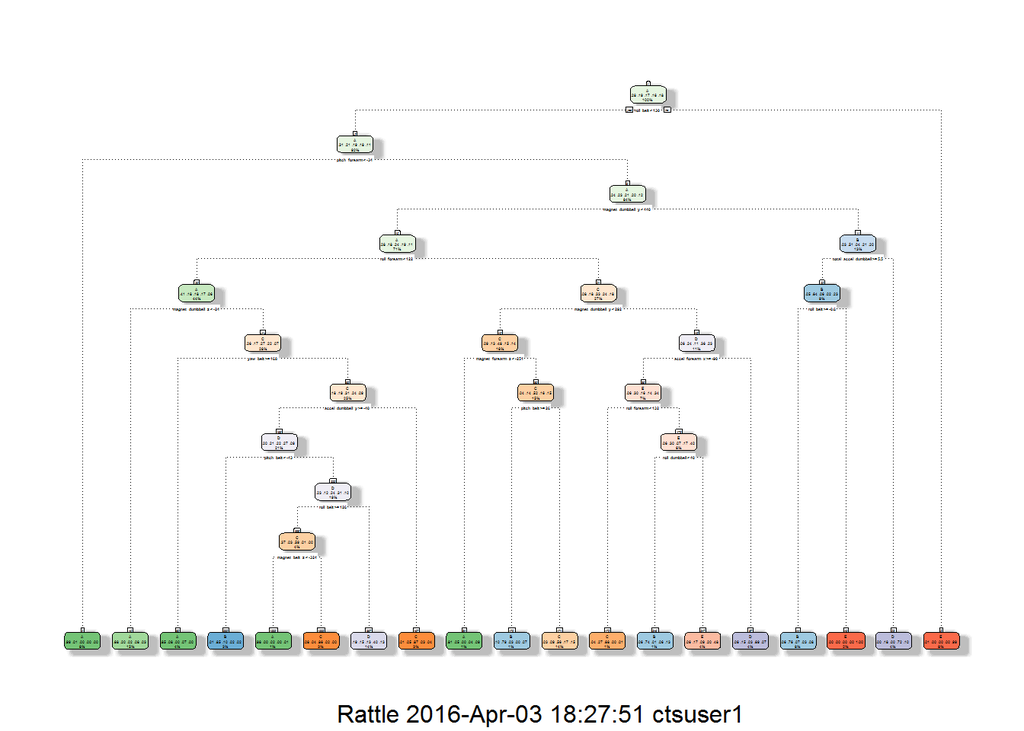

```r
library(rpart.plot)
library(RColorBrewer)
library(rattle)
modFitDT <- rpart(classe ~ ., data = trainingfinal, method="class")
fancyRpartPlot(modFitDT)
```

Prediction on cross validation set With Decision Tree

```r
prediction <- predict(modFitDT, trainingcv, type = "class")
confusionMatrix(prediction, trainingcv$classe)
```

```
## Confusion Matrix and Statistics
##
##           Reference
## Prediction    A    B    C    D    E
##          A 1854  297   28  127   43
##          B   42  771   65   26   70
##          C   56  146 1077  193  172
##          D  260  235  172  872  229
##          E   20   69   26   68  928
##
## Overall Statistics
##
##                Accuracy : 0.7012
##                  95% CI : (0.691, 0.7114)
##     No Information Rate : 0.2845
##     P-Value [Acc > NIR] : < 2.2e-16
##
##                   Kappa : 0.6225
##  Mcnemar's Test P-Value : < 2.2e-16
##
## Statistics by Class:
##
##                      Class: A Class: B Class: C Class: D Class: E
## Sensitivity            0.8306  0.50791   0.7873   0.6781   0.6436
## Specificity            0.9118  0.96792   0.9125   0.8634   0.9714
## Pos Pred Value         0.7893  0.79158   0.6551   0.4932   0.8353
## Neg Pred Value         0.9312  0.89130   0.9531   0.9319   0.9237
## Prevalence             0.2845  0.19347   0.1744   0.1639   0.1838
## Detection Rate         0.2363  0.09827   0.1373   0.1111   0.1183
## Detection Prevalence   0.2994  0.12414   0.2095   0.2253   0.1416
## Balanced Accuracy      0.8712  0.73791   0.8499   0.7707   0.8075
```

### Model Building & Prediction With Random Forest

Model Building with Random Forest

```r
library(randomForest)
modFitRF <- randomForest(classe ~ ., data = trainingfinal, ntree = 1000)
```

Prediction on cross validation set With Random Forest

```r
prediction <- predict(modFitRF, trainingcv, type = "class")
confusionMatrix(prediction, trainingcv$classe)
```

```
## Confusion Matrix and Statistics
##
##           Reference
## Prediction    A    B    C    D    E
##          A 2228    3    0    0    0
##          B    4 1514   10    0    0
##          C    0    1 1353   11    0
##          D    0    0    5 1273    1
##          E    0    0    0    2 1441
##
## Overall Statistics
##
##                Accuracy : 0.9953
##                  95% CI : (0.9935, 0.9967)
##     No Information Rate : 0.2845
##     P-Value [Acc > NIR] : < 2.2e-16
##
##                   Kappa : 0.994
##  Mcnemar's Test P-Value : NA
##
## Statistics by Class:
##
##                      Class: A Class: B Class: C Class: D Class: E
## Sensitivity            0.9982   0.9974   0.9890   0.9899   0.9993
## Specificity            0.9995   0.9978   0.9981   0.9991   0.9997
## Pos Pred Value         0.9987   0.9908   0.9912   0.9953   0.9986
## Neg Pred Value         0.9993   0.9994   0.9977   0.9980   0.9998
## Prevalence             0.2845   0.1935   0.1744   0.1639   0.1838
## Detection Rate         0.2840   0.1930   0.1724   0.1622   0.1837
## Detection Prevalence   0.2843   0.1947   0.1740   0.1630   0.1839
## Balanced Accuracy      0.9988   0.9976   0.9936   0.9945   0.9995
```

### Predicting on the Test Set using Random Forest

Since we see significantly greater accuracy with random forest algorithm, we apply random forest to the test set and print the predicted values of response variable

```r
testing <- read.csv("https://d396qusza40orc.cloudfront.net/predmachlearn/pml-testing.csv", na.strings=c("", "NA", "NULL", "#DIV/0!"))

dim(testing)
```

```
## [1]  20 160
```

```r
testpredictions <- as.character(predict(modFitRF,newdata=testing))
print(testpredictions)
```

```
##  [1] "B" "A" "B" "A" "A" "E" "D" "B" "A" "A" "B" "C" "B" "A" "E" "E" "A"
## [18] "B" "B" "B"
```